# How to use IRTnorm

Hannah M. Heister and Casper J. Albers and Marieke E. Timmerman

2026-11-19

# Install IRTnorm for the first time

IRTnorm estimates Bayesian IRT models using Stan. The Stan-based functions require the `cmdstanr` package and a working CmdStan installation. Fitting Stan models requires a modern C++ compiler and the GNU Make build utility. Installation instructions for your operating system are in the [CmdStan Guide](https://mc-stan.org/docs/cmdstan-guide/installation.html#cpp-toolchain).

Once the toolchain is installed, install `cmdstanr`, then CmdStan, then IRTnorm:

```r
install.packages("cmdstanr",
                 repos = c("https://stan-dev.r-universe.dev", getOption("repos")))
cmdstanr::install_cmdstan()
install.packages("IRTnorm")
```

More information about `cmdstanr` is available at https://mc-stan.org/cmdstanr/.

# Introduction

Norm-referenced psychological tests evaluate an individual’s performance relative to a reference population, typically using standardized scores such as T-, IQ- or z-scores (American Educational Research Association 2014). Many developmental and intelligence tests rely on reference populations that change continuously with age (Timmerman et al. 2025).

In such settings, item response theory (IRT)-based continuous norming models are useful for deriving age-specific norms. These models explicitly allow the latent trait distribution to depend on age. As a result, each individual’s latent trait estimate can be directly compared to the age-specific reference population using a z-standardized norm score (Heister et al. 2024). As in most parametric IRT models, the latent trait distribution is assumed to be normal in the reference population. Because the latent trait distribution of psychological tests typically can be assumed to change smoothly with age, the mean and standard deviation can be modeled as smooth functions of age, using polynomial regression or penalized splines.

Simulation studies have shown that IRT-based continuous norming models can accurately recover age-specific norms; further, an empirical evaluation with the intelligence test IDS-2 (Grob et al. 2018) has shown that these models can fit empirical data well (Heister et al. 2024). The default approach to norm psychological tests is to use raw score-based continuous norming (Timmerman et al. 2025). Unlike raw score-based continuous norming, IRT-based models use all available item-level information, can model multiple latent traits and their relationships, and integrate straightforwardly with adaptive testing.

`IRTnorm` implements a framework for deriving age-specific norm scores using Bayesian IRT-based continuous norming models. It includes tools for model comparison, model estimation, visual inspection of model fit, and norming of new individuals.

This vignette introduces the main modeling concepts of `IRTnorm` and demonstrates their use on a unidimensional test with binary items. For items with more than two ordered response categories (graded response model) and for tests with several domains (hierarchical models), see the `vignette("special cases")`, after reading this vignette. The models are fitted with Stan, so the package `cmdstanr` and a working CmdStan installation are required.

# Workflow overview

The main workflow in `IRTnorm` consists of four steps:

1. **Select a model** (`compare_IRTnorm_models()`, `compare_age_models()`, `visual_age_models()`).
2. **Fit the selected model** and extract all important model information (`estimate_norming_model()`).
3. **Evaluate model fit**:

   | Function | What it checks |
   | --- | --- |
   | `raw_score_ppc()`, `visual_raw_score_ppc()` | observed vs. model-implied raw score distributions |
   | `item_person_fit()` | observed vs. model-implied item and person properties |
   | `item_residual_cor()` | local independence of the items |
   | `quantile_curves()` | consistency of the estimates with the model-implied quantiles |
   | `normscore_dist()` | normality of the norm scores within age groups |
   | `effect_age()` | plausibility of the estimated age trajectories |
   | `cor_structure()` | correlations between domains (hierarchical models only, see `vignette("Norming_with_the_graded_response_model_and_hierarchical_models")`) |

4. **Norm new individuals** (`norm_new_individual()`).

# Norming a unidimensional test

We illustrate the workflow with a small simulated data set (`response_data`), to keep the example concise. The age variable in this data set is on a standardized scale, which is why ages such as -1 and age groups such as `seq(-2, 2, 1)` appear below. Item responses are binary and coded 0 and 1. The data is simulated under a 2PLnorm model with the latent trait mean and standard deviation regressed with a quadratic term (mu = 0.455 + 0.572age - 0.357 age^2; sigma = 0.538 * 0.154 age^2). In practical applications, larger data sets are usually required, with a larger number of items to obtain sufficiently precise estimates of the latent trait scores and a larger sample size to obtain sufficiently precise norm estimates.

```r
library(IRTnorm)
library(ggplot2)
data("response_data")
```

## 1. Select a model

Selecting an appropriate IRT-based norming model requires considering a set of plausible models. The models can differ in the specific IRT model, in the specification of the age effects, or in both. We first choose the IRT model and then the age model.

### Choosing the IRT model

Candidate IRT models should be selected based on the characteristics of the test. For example, if the test consists of binary items and guessing might influence the responses, a 3PL-norm model can be evaluated alongside a 2PL-norm model. If guessing is unlikely, 1PL- and 2PL-norm models are sufficient.

The function `compare_IRTnorm_models()` fits the models and compares their expected log predictive density (ELPD), estimated with approximate leave-one-out cross-validation (LOO-CV) using the `loo` package (Vehtari et al. 2026).

The models are specified in the `model_specifications` argument, a list with one element per model. Each element is itself a list that contains at least `irt_model` (the IRT model) and `age_model` (`"poly"` for polynomial regression or `"splines"` for penalized splines). Additional options depend on the age model; see `?estimate_norming_model` for all of them.

For a fair comparison, use the same age model in all models, with polynomial degrees high enough to capture the underlying trajectory. Here, we use a fourth-degree polynomial for the mean and a third-degree polynomial for the standard deviation. By default, 500 warm-up and 500 sampling iterations are used per chain, which keeps the computation time low. More iterations can improve precision for complex comparisons, but we keep the default here.

The data are supplied via `raw_data`, a `data.frame` or `matrix` with the individuals’ ages and item responses. The age variable (`age_variable`) and the item variables (`item_variables`) can be given by name or by column position.

```r
model_list <- list(
  list(irt_model = "1PLnorm", age_model = "poly",
       poly_mean = 4, poly_sd = 3),
  list(irt_model = "2PLnorm", age_model = "poly",
       poly_mean = 4, poly_sd = 3)
)

IRTmods <- compare_IRTnorm_models(model_specifications = model_list,
                                  raw_data = response_data,
                                  age_variable = "age",
                                  item_variables = 1:50)
```

The result contains the model comparison (`best_model`) and sampling diagnostics (`diagnostics`). Before interpreting the ELPD differences, we assess the reliability of the LOO approximation by examining the number of observations with Pareto $k$ values above 0.7.

```r
sum(IRTmods$diagnostics$pareto_k > 0.7)
```

```
#> [1] 0
```

No Pareto $k$ value exceeds 0.7, so the LOO approximation is stable enough to rely on the ELPD differences.

```r
IRTmods$best_model
```

```
#>                ELPD irt_model age_model poly_mean poly_sd modelcombi ELPD_diff
#> 2_2PLnorm -11016.76   2PLnorm      poly         4       3        4_3    0.0000
#> 1_1PLnorm -11142.57   1PLnorm      poly         4       3        4_3 -125.8042
#>                 SE rank
#> 2_2PLnorm  0.00000    1
#> 1_1PLnorm 16.86381    2
```

`ELPD_diff` is the difference in ELPD to the best model, and `SE` is the standard error of this difference. We recommend selecting the more complex IRT model if its ratio `ELPD_diff / SE` is below -1.96. This is a guideline only; the best decision rule depends on the application, and other rules may be defensible. In this example, the recommended selection criterion is met, and we therefore select the 2PL-norm model for the remainder of the analysis.

### Choosing the age model

Next, we determine the most appropriate specification of the age effect. The function `compare_age_models()` (available for unidimensional models only) compares age models by their ELPD, either over a user-specified grid of polynomial degrees (`method = "grid"`) or by forward selection (`method = "forward"`). Forward selection starts with the simplest model and increases the polynomial degree of the mean or the standard deviation step by step, as long as the ELPD improves, up to a maximum number of model fits (`maxeval`). It is usually more efficient than a grid search, but because it is greedy, it can miss better combinations. Setting `include_splines = TRUE` additionally compares the polynomial models with penalized splines.

```r
agemodel_2PL <- compare_age_models(method = "forward",
                                   irt_model = "2PLnorm",
                                   raw_data = response_data,
                                   age_variable = "age",
                                   item_variables = 1:50,
                                   include_splines = TRUE)
```

Again, we first assess whether the LOO approximation is stable.

```r
colSums(agemodel_2PL$paretok > 0.7)
```

```
#>  [1] 0 0 0 0 0 1 1 0 0 0 0 0
```

Two of the evaluated models have Pareto $k$ values above 0.7. To see whether these influential observations affect the model selection, we repeat the forward selection with these responses set to missing. First, we identify the influential responses. Then, we create a new data set, `response_data_excl`, in which they are missing.

```r
temp <- data_prep(raw_data = response_data,
                  age_variable = "age",
                  item_variables = 1:50,
                  age_model = "splines")

excl <- unique(unlist(lapply(seq_len(ncol(agemodel_2PL$paretok)), function(i) {
  which(agemodel_2PL$paretok[, i] > 0.7)
})))

# temp$jj: person index, temp$ii: item index of each response.
# The "+ 1" skips the age column, which is the first column of response_data.
response_data_excl <- response_data
for (ex in excl) {
  response_data_excl[temp$jj[ex], temp$ii[ex] + 1] <- NA
}

agemodel_2PL_excl <- compare_age_models(method = "forward",
                                        irt_model = "2PLnorm",
                                        raw_data = response_data_excl,
                                        age_variable = "age",
                                        item_variables = 1:50,
                                        include_splines = TRUE)
```

```r
colSums(agemodel_2PL_excl$paretok > 0.7)
```

```
#>  [1] 0 0 0 0 0 0 0 0 0 0 0 0
```

After excluding the two influential responses, no highly influential observations remain. This will not always be the case. Our aim is to check how much the influential observations affect the model selection, so we compare the ELPD of both data sets.

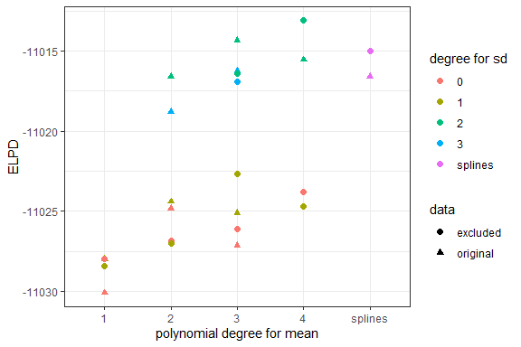

```r
combi <- cbind(rbind(agemodel_2PL$best_model, agemodel_2PL_excl$best_model),
               data = c(rep("original", nrow(agemodel_2PL$best_model)),
                        rep("excluded", nrow(agemodel_2PL_excl$best_model))))
combi$poly_mean[is.na(combi$poly_mean)] <- "splines"
combi$poly_sd[is.na(combi$poly_sd)] <- "splines"

ggplot(combi) +
  geom_point(aes(poly_mean, ELPD, shape = data, color = poly_sd), size = 2) +
  labs(x = "polynomial degree for mean", color = "degree for sd",
       shape = "data") +
  theme_bw()
```

The magnitude of the ELPD differs slightly between the two data sets (original and excluded), but the general pattern is the same. The ELPD is highest, indicating the favored model, for both data sets, when using a second-degree polynomial for the standard deviation. Only for the mean is there a small discrepancy: the original data favor the third-degree polynomial, and the data without the influential responses favor the fourth-degree polynomial.

Because these differences in performance are small, we argue that the selection should be based not only on the ELPD, but also on the resulting estimated trajectories. To inspect them, use `perspective = "trajectory"` in `visual_age_models()`. The number of highlighted top-ranked models is set with `highlight_ranks`.

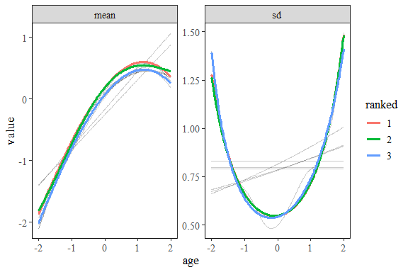

```r
visual_age_models(agemodel_2PL, perspective = "trajectory", highlight_ranks = 3)
```

Let’s assume we have strong theoretical reasons to expect that the mean of the latent trait does not decrease substantially with age. We therefore select the model with the trajectory that keeps the mean as stable as possible for older individuals, which is the model with the second-best ELPD rank. The ELPD plot shows that this is the model with a fourth-degree polynomial for the mean and a second-degree polynomial for the standard deviation. In this plot, the y-axis is the ELPD difference divided by its standard error, so values close to 0 indicate models that are hard to distinguish from the best model.

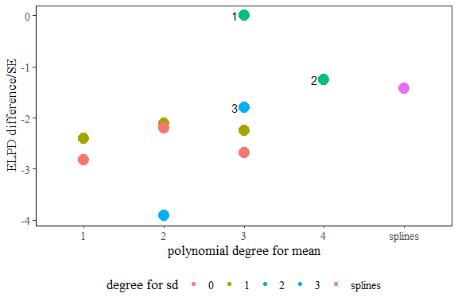

```r
visual_age_models(agemodel_2PL, perspective = "ELPD", highlight_ranks = 3)
```

## 2. Fit the selected model

Once the norming model has been selected, it is refitted with a sufficient number of iterations to obtain the final estimates. The function `estimate_norming_model()` fits the model and extracts all information needed for evaluating the model and norming new individuals.

```r
info <- estimate_norming_model(raw_data = response_data,
                               age_variable = "age",
                               item_variables = 1:50,
                               irt_model = "2PLnorm",
                               age_model = "poly",
                               poly_mean = 4,
                               poly_sd = 2,
                               seed = 1234,
                               iter_warmup = 2000,
                               iter_sampling = 2000,
                               extract_stan_object = TRUE)
```

### Check convergence

Reliable inference requires that the MCMC sampler has converged. We start with the numerical diagnostics.

First, the model should have no divergent transitions:

```r
sum(info$model_stan_obj$sampler_diagnostics()[, , "divergent__"])
```

```
#> [1] 0
```

Two further key diagnostics are the potential scale reduction factor (R-hat) and the effective sample size (ESS). R-hat should be close to 1 (commonly, below 1.01), indicating agreement between the chains. Larger ESS values indicate more precise estimates. As a rule of thumb, an ESS of at least 400 is generally recommended for reliable estimation, although higher values may be needed for precise estimation of tail quantities or other specific quantities of interest.

```r
info$conv_info
```

```
#>    diagnostic variable         Min.      1st Qu.       Median         Mean
#> 1        rhat  z_theta    0.9996654     1.000185     1.000508     1.000593
#> 2        rhat p1_theta    1.0001329     1.000598     1.001736     1.002732
#> 3        rhat p2_theta    1.0009534     1.001187     1.001421     1.001987
#> 4        rhat    alpha    0.9999813     1.000361     1.000533     1.000661
#> 5        rhat     beta    1.0008476     1.002377     1.004243     1.004141
#> 6    ess_bulk  z_theta 3673.6692858 11693.270638 13862.864217 12780.782894
#> 7    ess_bulk p1_theta  673.7645581  1957.398325  2265.819149  2029.973189
#> 8    ess_bulk p2_theta 2262.4614992  2555.985095  2849.508691  2718.608270
#> 9    ess_bulk    alpha 3992.4169491  5831.177571  6389.001970  6339.181713
#> 10   ess_bulk     beta  666.2113183   753.971224   943.526517  1170.849857
#> 11   ess_tail  z_theta 4134.7031409  5478.672064  5719.767606  5698.072666
#> 12   ess_tail p1_theta 1206.5841758  2811.799389  3638.894017  3151.992843
#> 13   ess_tail p2_theta 4113.2943029  4404.226769  4695.159235  4596.552030
#> 14   ess_tail    alpha 4133.2040104  5311.086068  5596.374923  5592.931996
```

[output cut: 17 more lines]

In this example, R-hat is below 1.01 for all parameter groups, and the ESS exceeds 400 for all parameters, indicating good convergence. The bulk and tail ESS (`ess_bulk` and `ess_tail`) are also similar. A substantial difference between them can indicate sampling problems that need further investigation.

The numerical diagnostics should be complemented by visual checks for key parameters, such as the regression coefficient of the latent trait mean (`p1_theta`). Trace plots show whether the chains mix well:

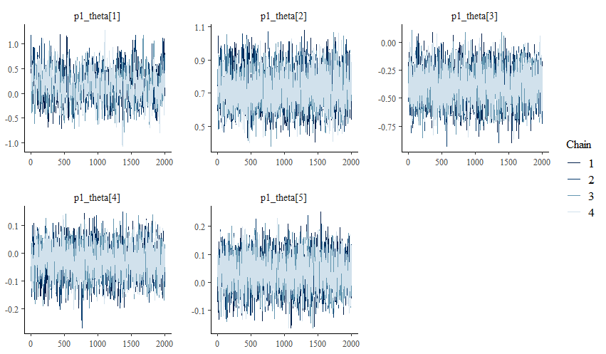

```r
library(bayesplot)
conv_plot <- bayesplot::mcmc_trace(info$model_stan_obj$draws(c("p1_theta")))
conv_plot
```

In this example, the chains overlap substantially and move freely through the same region of the parameter space, without visible trends, drifts, or abrupt jumps, as desired. Rank plots additionally reveal convergence problems in the posterior tails:

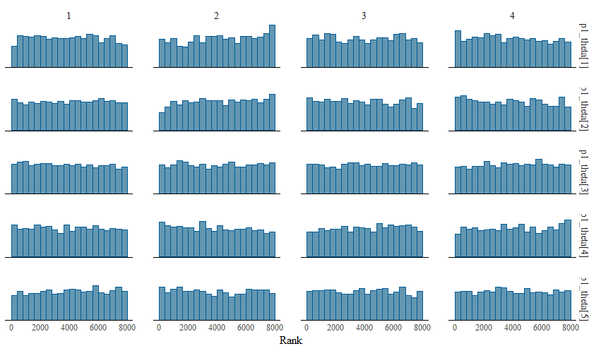

```r
hist_plot <- bayesplot::mcmc_rank_hist(info$model_stan_obj$draws(c("p1_theta")))
hist_plot
```

In this example, the rank plots look approximately uniform, indicating good convergence.

If the trace plots show systematic patterns, the rank plots are clearly not uniform, R-hat is high, or the ESS is low, the model needs more sampling. A good first step is to increase the number of warm-up iterations (`iter_warmup`) before considering other adjustments.

## 3. Evaluate model fit

Once convergence has been established, we evaluate how well the model fits the observed data. Each of the following checks looks at a different aspect of the model.

### Raw score distribution

A useful first diagnostic is to compare the observed raw score distribution with the distribution implied by the fitted model (a posterior predictive check). It is computed with `raw_score_ppc()` and plotted with `visual_raw_score_ppc()`. We begin with the complete sample.

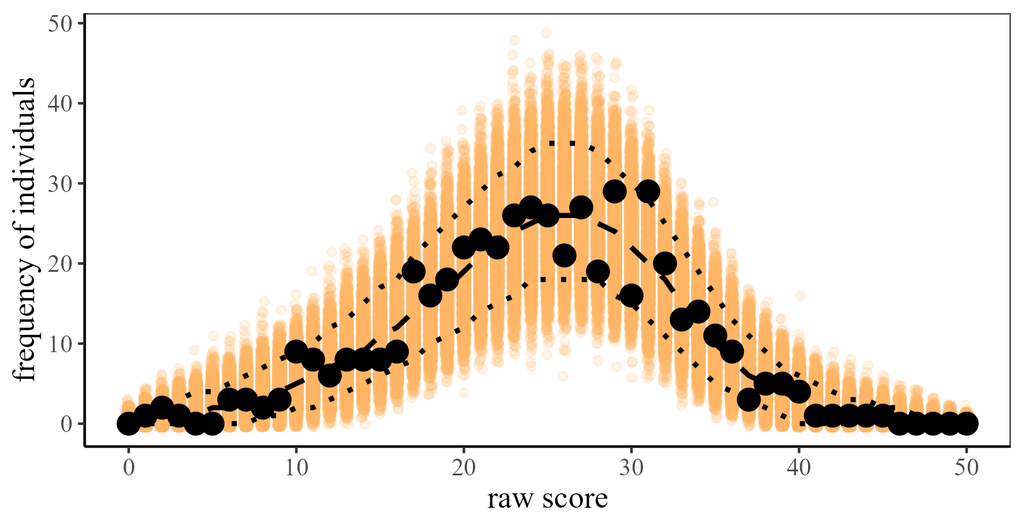

```r
raw_ppc <- raw_score_ppc(fit_info = info)
visual_raw_score_ppc(raw_ppc)
```

The black points are the observed frequencies of each raw score, the orange points are the frequencies in the replicated data (one point per posterior draw), and the dotted lines mark the 90% credible interval. Most observed raw scores lie within the interval, and all observed values fall within the range of the replicated data. The fitted model therefore reproduces the observed raw score distribution well.

To assess the fit within the age range, repeat the evaluation for age groups with the `age_range` argument, which gives the boundaries of the age groups on the scale of the age variable.

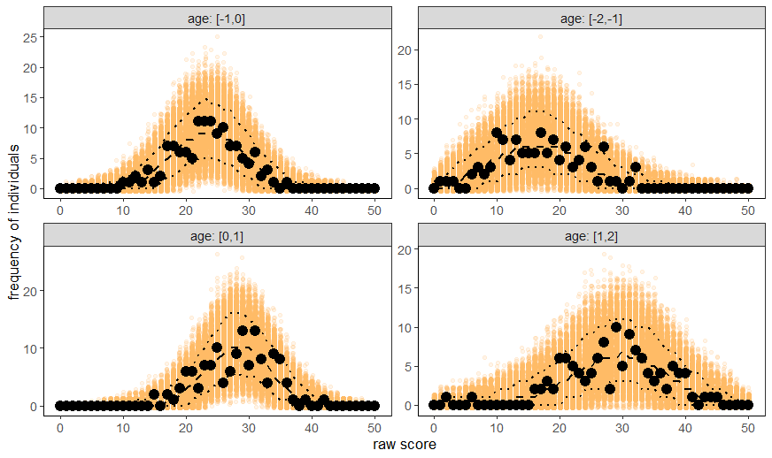

```r
raw_ppc_age <- raw_score_ppc(fit_info = info,
                             age_range = seq(-2, 2, 1))
visual_raw_score_ppc(raw_ppc_age)
```

The observed raw score distributions appears consistent with those implied by the model in all age groups.

### Local independence

IRT models assume that items are conditionally independent given the latent trait. This can be checked with the correlations between the item residuals (Yen’s Q3), computed with `item_residual_cor()`. The function prints a summary of the correlations between distinct items and plots them as a heat map.

```r
item_residual_cor(fit_info = info)
```

```
#>     Min.  1st Qu.   Median     Mean  3rd Qu.     Max.
#> -0.18830 -0.04377 -0.01201 -0.01364  0.01850  0.14197
```

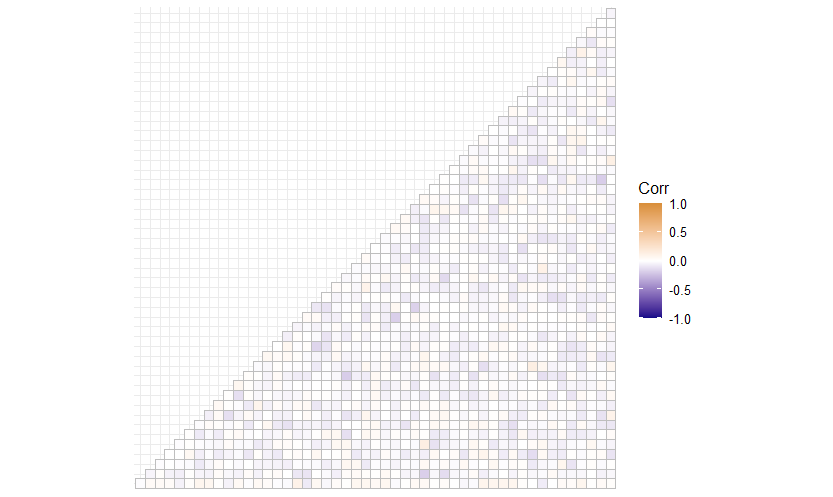

The residual correlations are low and do not exceed 0.2, a value commonly used as a rule of thumb for flagging local dependence. We therefore conclude that the local independence assumption is plausible.

### Item fit

To examine the fit in more detail, `item_person_fit()` compares observed and model-implied properties of the items and persons. We start with the item fit, which compares the observed and model-implied proportion of correct responses per item.

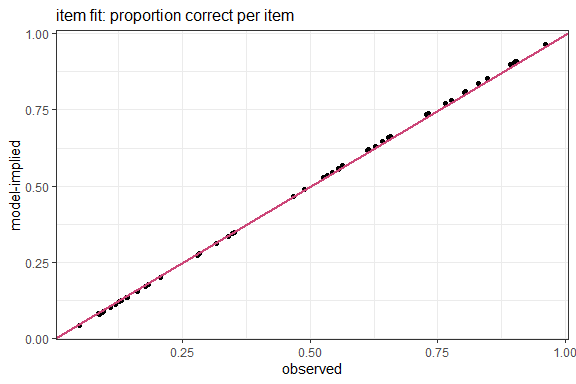

```r
item_person_fit(fit_info = info, parameter = "item")
```

The observed and model-implied proportions are in close agreement, indicating that the estimated item parameters describe the observed data adequately.

### Person fit

Next, we evaluate the person-level fit, which compares the observed and model-implied raw score of each person.

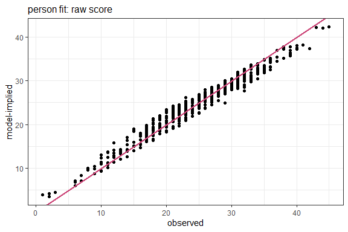

```r
item_person_fit(fit_info = info, parameter = "person")
```

The observed and model-implied raw scores are in close agreement. A slight systematic regression towards the mean pattern is visible: for high-performing individuals, the model predicts a somewhat lower raw score than observed, and for low-performing individuals, a somewhat higher one. Regression towards the mean is common in Bayesian IRT models, because the estimates of the latent trait are slightly shrunk towards the prior mean. The more informative the test, the smaller this effect. It does not indicate poor model fit, but it should be kept in mind when interpreting the results.

### Internal consistency

The following checks examine whether the different parts of the model are consistent with each other. A model without inconsistencies is not guaranteed to fit well overall, but inconsistencies point to issues.

First, `quantile_curves()` compares the estimated latent trait values of the individuals with the quantile curves implied by the model. About 5% of the points should lie below the 5% curve, about 25% below the 25% curve, and so on.

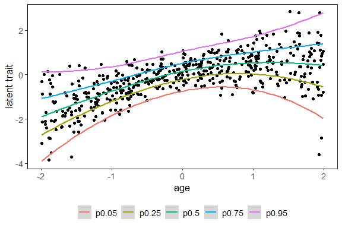

```r
quantile_curves(fit_info = info,
                probs = c(0.05, 0.25, 0.5, 0.75, 0.95))
```

The model-implied quantile curves follow the estimated latent trait values closely, indicating that the fitted model is internally consistent.

Second, the model assumes that the normed latent trait follows a standard normal distribution conditional upon age. This can be assessed by considering the distribution within age groups. The function `normscore_dist()` plots a histogram of the estimated norm scores for each age group specified, together with the density of the standard normal distribution.

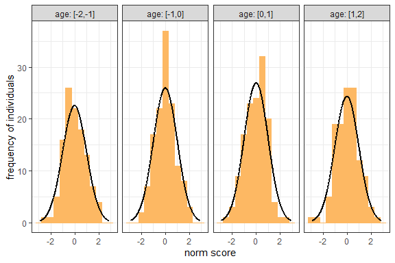

```r
normscore_dist(fit_info = info, age_range = seq(-2, 2, 1), binwidth = 0.5)
```

The distributions are approximately normal in all age groups specified, which further supports the consistency of the fitted model.

Finally, `effect_age()` shows how the mean and the standard deviation of the latent trait vary with age. These trajectories should be evaluated against substantive or theoretical expectations.

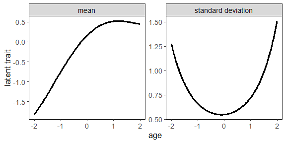

```r
effect_age(fit_info = info)
```

The estimated age effects closely resemble those used to generate the data, which suggests that the model captures the relationship between age and the latent trait well.

## 4. Norm new individuals

Suppose a new individual has the item responses `y` and the age `age`. The responses must be coded in the same way as the data used to fit the model (here 0 and 1). Missing item responses (`NA`) are allowed.

```r
y <- c(1,1,0,0,1,0,1,1,0,0,1,0,0,1,1,0,0,1,1,0,1,1,1,0,1,0,1,1,1,1,1,1,0,0,0,
       1,0,1,1,0,0,0,0,1,1,1,0,1,0,0)
age <- -1
```

To norm the individual, the fitted model is applied with the posterior draws of the item parameters and of the latent trait distribution. Only the individual’s latent trait is estimated, and all other parameters stay fixed at their posterior draws. The norm score is the estimated latent trait relative to the latent trait distribution of the reference population at the individual’s age. The new data are therefore only used to estimate the individual’s own latent trait. The fitted model is not updated.

The estimation uses random numbers, so we set a seed to make the result reproducible.

```r
set.seed(1234)
info_newperson <- norm_new_individual(new_y = y, new_age = age,
                                      fit_info = info)

# summary of the individual's norm score
info_newperson$summary
```

```
#> $mean
#> [1] 0.9399413
#>
#> $sd
#> [1] 0.4818565
#>
#> $median
#> [1] 0.9366068
#>
#> $ci
#>         2.5%        97.5%
#> 0.0006555537 1.8933113084
```

The best estimate of the individual’s norm score is 0.939, which is approximately 0.9 standard deviations above the average of individuals of the same age. The 95% credible interval of the norm score ranges from 0.001 to 1.893. The individual is therefore likely to perform above average, but there is limited evidence that the performance is exceptionally high.

# Other models

This vignette used the 2PL-norm model for a unidimensional test with binary items. For tests with ordered response categories (graded response model) or with several domains (hierarchical models), the workflow is the same, with a few additional inputs and fit checks. These are described in the `vignette("Norming_with_the_graded_response_model_and_hierarchical_models")`.

# Funding

Development of `IRTnorm` was supported by Dutch Research Council NWO, [grant 406.27.GO.022](https://doi.org/10.61686/YHUOB23106).

# References

American Educational Research Association. 2014. *Standards for Educational and Psychological Testing*. American Educational Research Association.

Grob, Alexander, Priska Hagmann-von Arx, Selma Ruiter, Marieke Timmerman, and Linda Visser. 2018. *IDS-2: Intelligentie-En Ontwikkelingsschalen Voor Kinderen En Jongeren*. Hogrefe Publishing.

Heister, Hannah M, Casper J Albers, Marie Wiberg, and Marieke E Timmerman. 2024. “Item Response Theory-Based Continuous Test Norming.” *Psychological Methods*, ahead of print. https://doi.org/10.1037/met0000686.

Timmerman, Marieke E, Annelies De Bildt, and Julian Urban. 2025. “The GRoNC-Checklist: Guidelines for Reporting on Norm-Referenced and Criterion-Referenced Scores.” *Submitted*.

Vehtari, Aki, Jonah Gabry, Måns Magnusson, et al. 2026. *Loo: Efficient Leave-One-Out Cross-Validation and WAIC for Bayesian Models*. https://mc-stan.org/loo/.